# Foraging Simulation

Ben Weinstein

2017-06-12 10:48:10

# 1 Parameters

## 1.1 Empirical parameters estimated from whale tagging data

Behavior allocation (Foraging,Traveling) at each time step

$$state_t \sim(Binomial(\alpha))$$

Average maximum depth

$$Normal(\mu = dive_\mu, sd= \frac{1}{dive_\tau})$$

Average number of dives

$$Poisson(\lambda = dive_{count})$$

## 1.2 Parameters estimated from literature

Initial body mass (Tyson et al. 2016, Lockyer 1976)

$$M = 39614 kg$$

Metabolic rate while traveling Tyson et al. (2016),Williams et al. (2001).

$$m_{traveling} = -2.32 \frac{KJ}{sec}$$

Metabolic rate while foraging Tyson et al. (2016),Williams et al. (2001).

$$m_{foraging} = -4.14 \frac{KJ}{sec}$$

Lunges at depth, Ware 2011 reported ~40 sec interlunge time, with 1.5m/s dive speed.

$$Lunges \sim Poisson(\lambda=\frac{\text{dive_depth}}{50})$$

Energetic cost per lunge (Tyson et al. 2016)

$$E_{lunge} = -298.08 KJ$$

**this seems widly too low**

Energetic gain per lunge 41KJ/sec (Tyson et al 2016) and 15.5 sec per lunge (Ware et al. 2011)

$$41 \frac{KJ}{sec} * 15.5 \frac{sec}{lunge} = 635 \frac{KJ}{Lunge}$$

Metabolic efficiency, energy lost to extretion (Bejarano et al. 2017)

$$Beta(43.60,5.71)$$

Raw results

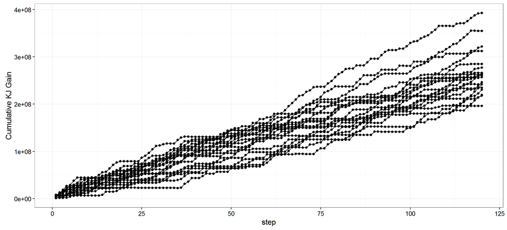

Scaled by time

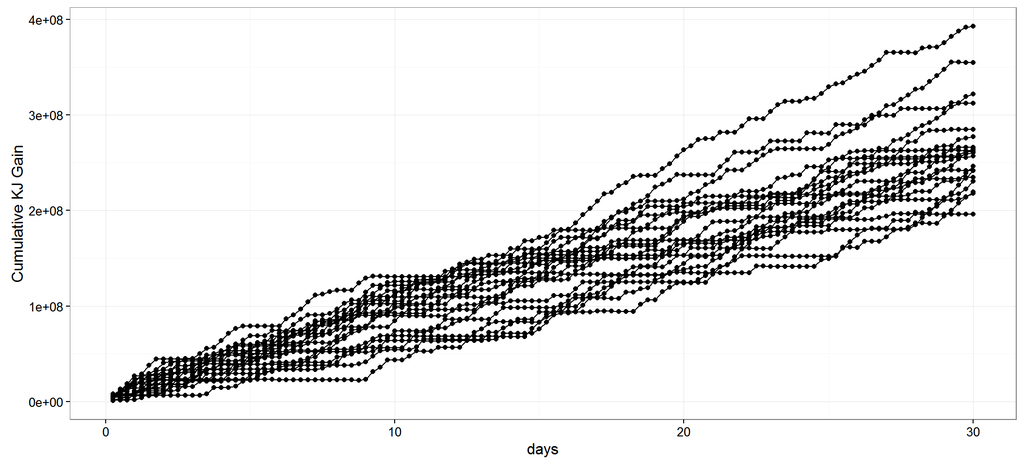

# 2 Questions and Improvements

- How to convert from energy to grams? Weight of blubber?
- Need to improve the dive count mixture distribution
- Include dive duration, where would it help inference?
- Are we double containing metabolic costs of foraging and costs of lunges?
- Mass specific effects?
- Parameter bounds for all variables

# 3 Future simulation directions

- Variable krill swarm size
- Variable krill quality
- Temporal variation in foraging rates, depths
- Explicitely spatial structure, movement, krill swarms, etc.
- Sensitivity